# ClassesTakenToProficiency

## Exploratory Data Analysis

Only using selected classes as all other classes in data set are commmon among all students within data set

### Stats comfort

```
##   stat.comf   PSTAT_100   PSTAT_115   PSTAT_131   PSTAT_134   PSTAT_160
##  1.00000000  0.06639935  0.08624924  0.06591115  0.07966783 -0.10097405
##   PSTAT_174   PSTAT_175       CS_16
## -0.17822376 -0.16164260 -0.17427633
```

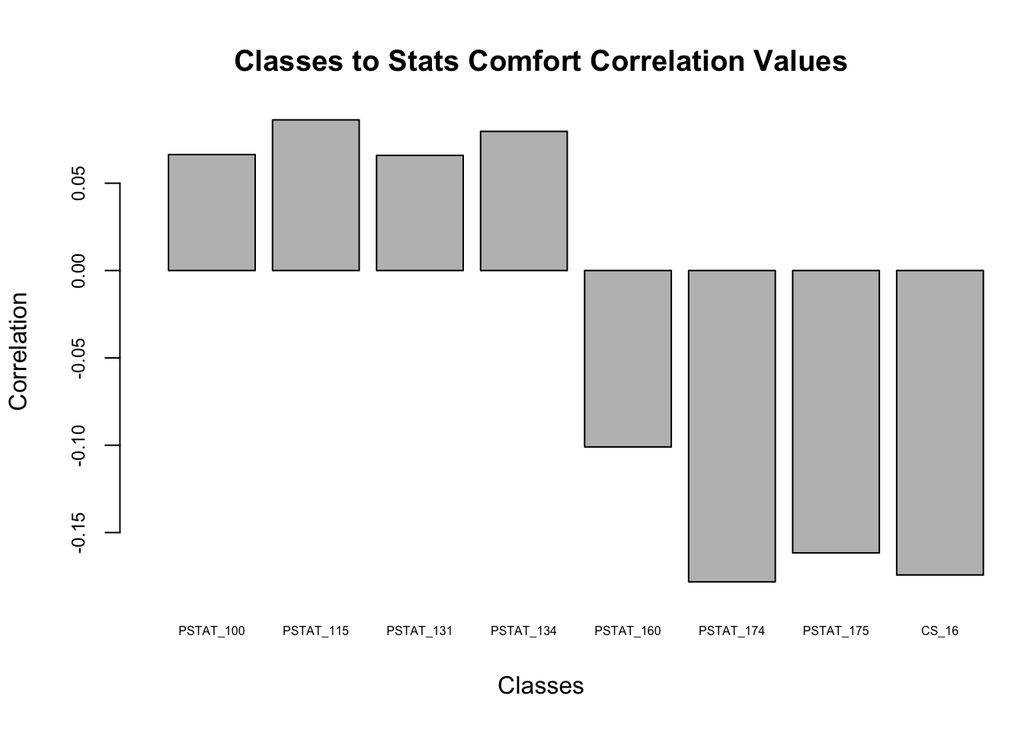

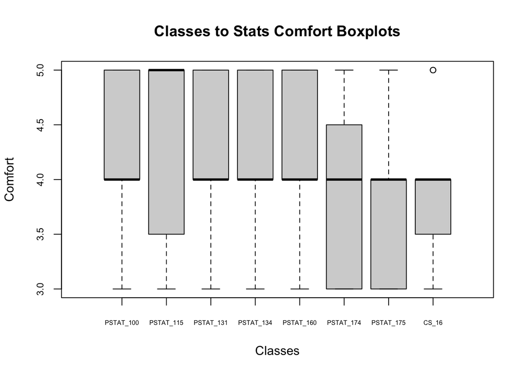

### Stats proficiency

Shows high correlation towards pstat 100, 115, and 131. Bit weird because those are the more coding heavy classes and not stats heavy classes. Negative correlation for pstat 134. Negative correlation for 160, 174, and 175 is also interesting bc they are the more advanced theoretical stats classes. Boxplots shows this same trend but also highlights heavy variation and overlap from groups.

```
##   stat.prof   PSTAT_100   PSTAT_115   PSTAT_131   PSTAT_134   PSTAT_160
##  1.00000000  0.07275726  0.17534472  0.30842368 -0.03876704 -0.08703883
##   PSTAT_174   PSTAT_175       CS_16
## -0.17069719 -0.11236664 -0.31101230
```

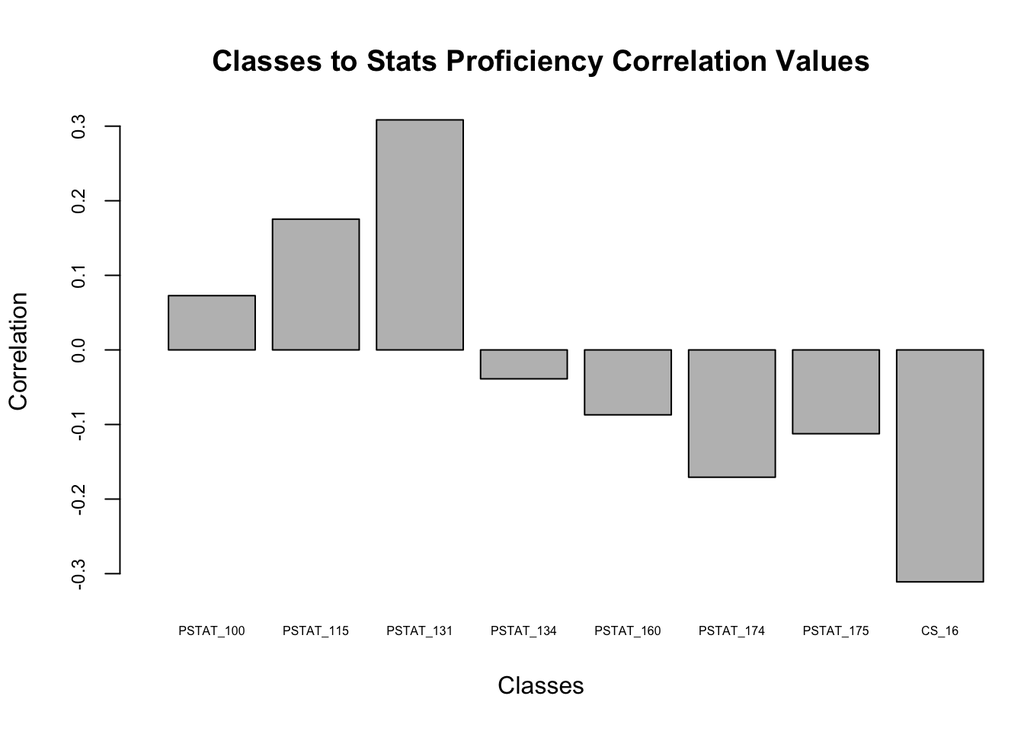

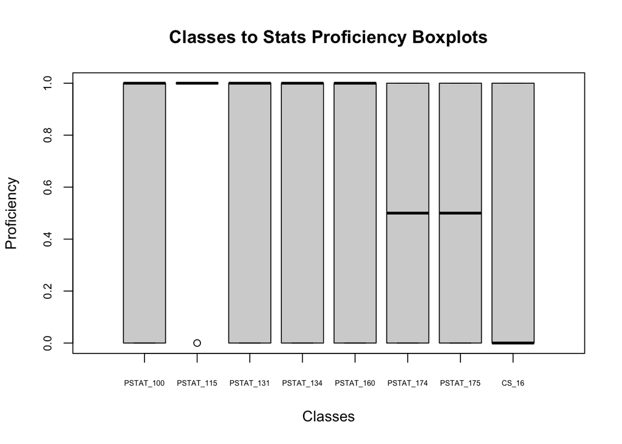

### Math comfort

Math comfort is fairly random among classes.

```
##   math.comf   PSTAT_100   PSTAT_115   PSTAT_131   PSTAT_134   PSTAT_160
##  1.00000000 -0.01594032 -0.10372348  0.12892073  0.03943379 -0.19069252
##   PSTAT_174   PSTAT_175       CS_16
##  0.03739788  0.09437014  0.08999541
```

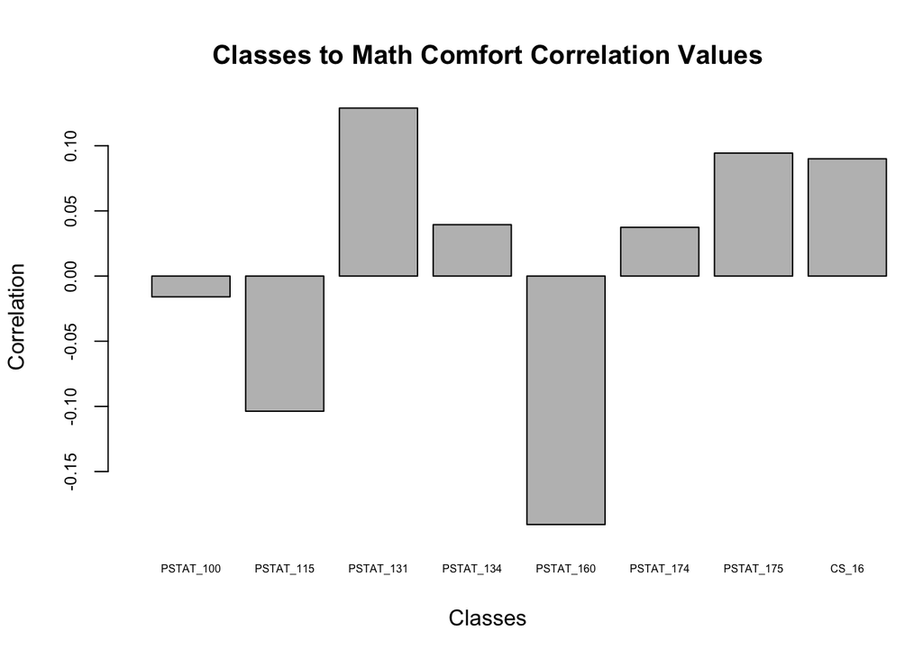

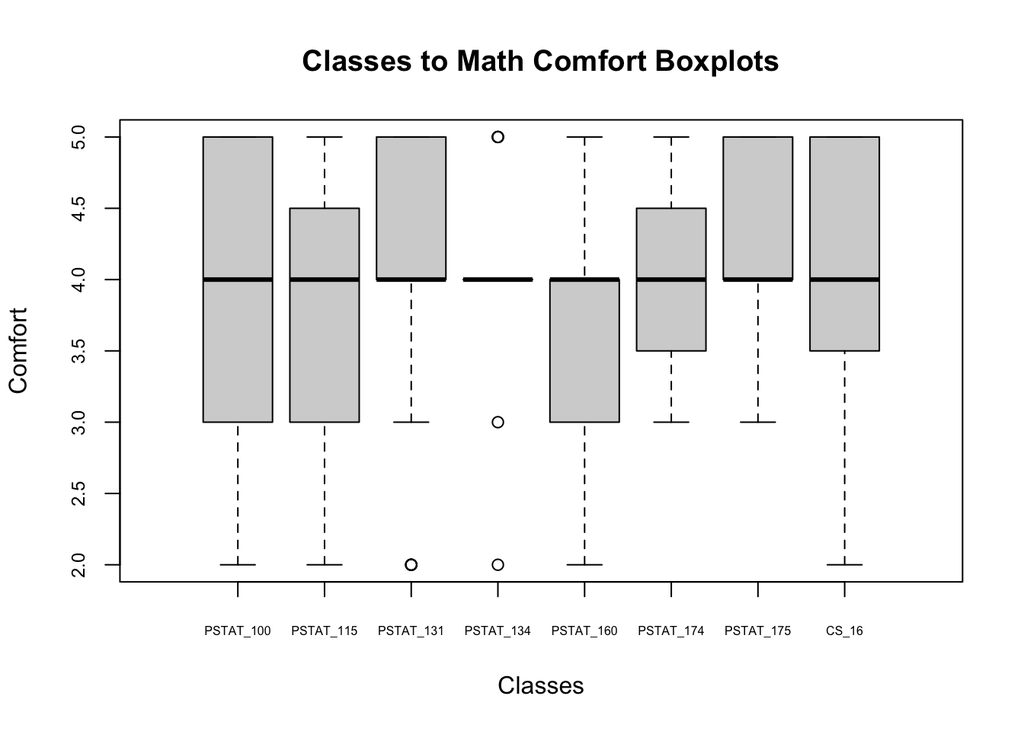

### Math proficiency

Shows similar trend as stats where the stats classes that actualy utilize a lot of theoretical and advanced math show negative correlation with proficiency.

```
##   math.prof   PSTAT_100   PSTAT_115   PSTAT_131   PSTAT_134   PSTAT_160
##  1.00000000  0.03767888 -0.10215671  0.14185987 -0.12368452 -0.16903085
##   PSTAT_174   PSTAT_175       CS_16
## -0.18232322 -0.18184824  0.04558423
```

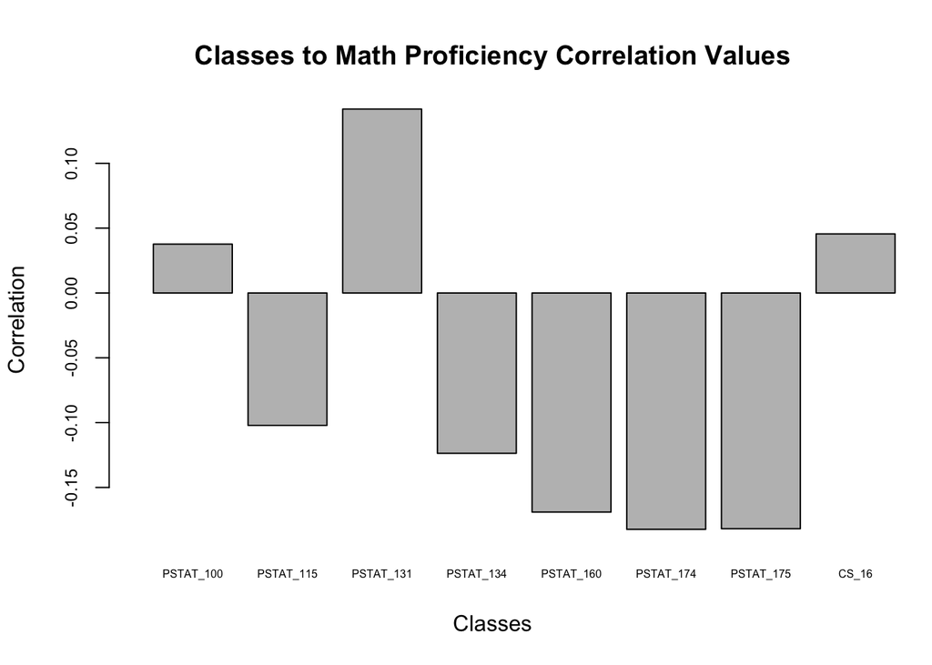

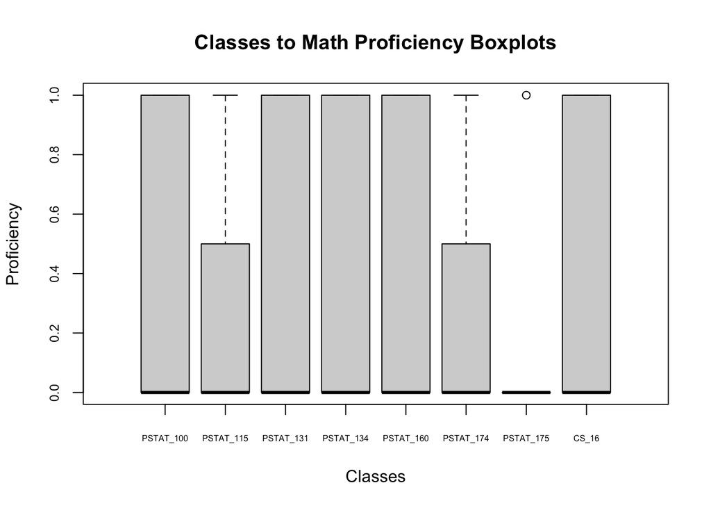

### Programming comfort

Programming comfort Shows high correlation towards pstat 100, 115, 131, and 134. Negative correlation for 160, 174, and 175. Interestingly enough no strong correlation for computer science classes.

```
##   prog.comf   PSTAT_100   PSTAT_115   PSTAT_131   PSTAT_134   PSTAT_160
##  1.00000000  0.06501579  0.15668780  0.22276504  0.34995662 -0.11111111
##   PSTAT_174   PSTAT_175       CS_16
## -0.02905424 -0.01912584 -0.04869221
```

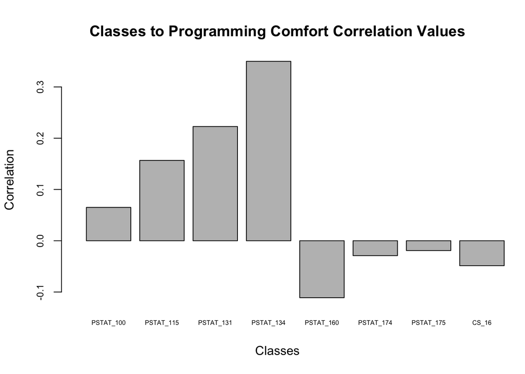

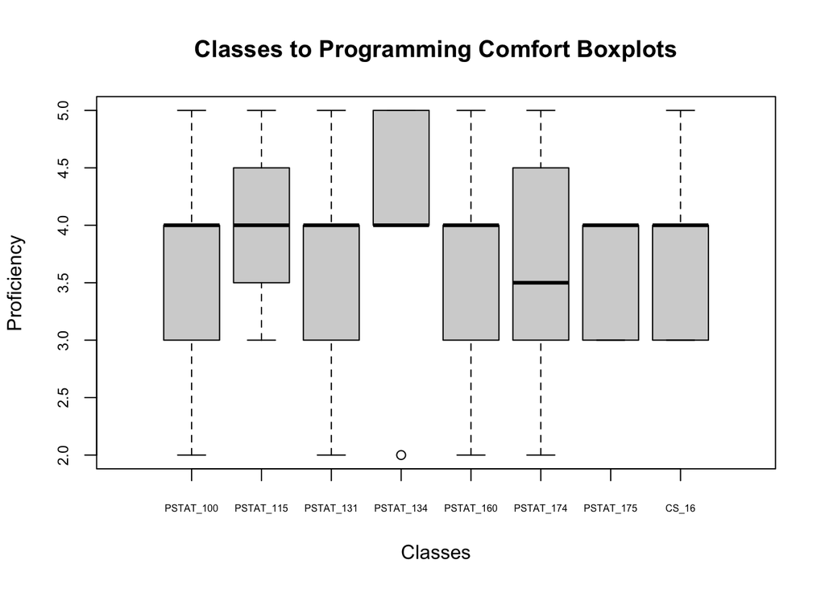

### Programming proficiency

Programming comfort Shows high proficiency towards pstat 131 and 134. Pretty much no correlation for other stats classes. Interestingly enough there is a negative correlation for cs 16.

```
##    prog.prof    PSTAT_100    PSTAT_115    PSTAT_131    PSTAT_134    PSTAT_160
##  1.000000000 -0.009752369  0.022160132  0.270426394  0.217927531  0.025000000
##    PSTAT_174    PSTAT_175        CS_16
## -0.004902903 -0.058094750 -0.155065968
```

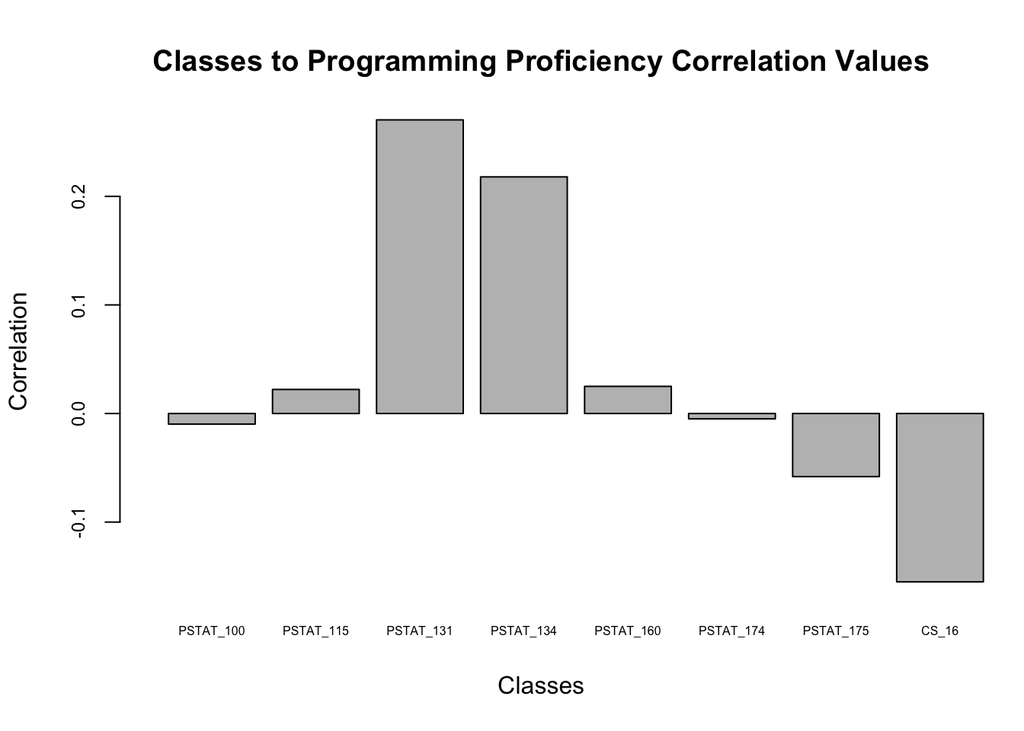

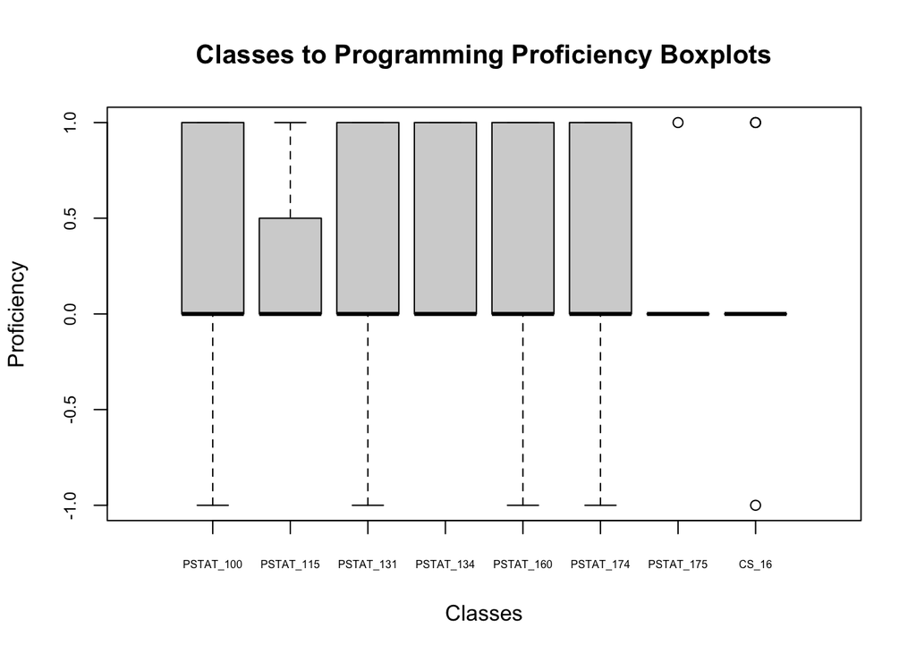

## Data analysis

```r
comf_stat <- lm(stat.comf ~ PSTAT_100+PSTAT_115+PSTAT_131+PSTAT_134+PSTAT_160+PSTAT_174+PSTAT_175+CS_16, data = mini)
summary(comf_stat)
```

```
##
## Call:
## lm(formula = stat.comf ~ PSTAT_100 + PSTAT_115 + PSTAT_131 +
##     PSTAT_134 + PSTAT_160 + PSTAT_174 + PSTAT_175 + CS_16, data = mini)
##
## Residuals:
##     Min      1Q  Median      3Q     Max
## -1.4920 -0.3573 -0.1148  0.5880  1.1579
##
## Coefficients:
##             Estimate Std. Error t value Pr(>|t|)
## (Intercept)  4.28810    0.37918  11.309 2.52e-14 ***
## PSTAT_100    0.02526    0.21318   0.118    0.906
## PSTAT_115    0.35198    0.32785   1.074    0.289
## PSTAT_131    0.04394    0.34970   0.126    0.901
## PSTAT_134    0.22898    0.25200   0.909    0.369
## PSTAT_160   -0.21725    0.23462  -0.926    0.360
## PSTAT_174   -0.36465    0.25743  -1.417    0.164
## PSTAT_175   -0.31147    0.33532  -0.929    0.358
## CS_16       -0.20284    0.25319  -0.801    0.428
## ---
## Signif. codes:  0 '***' 0.001 '**' 0.01 '*' 0.05 '.' 0.1 ' ' 1
##
## Residual standard error: 0.7059 on 42 degrees of freedom
## Multiple R-squared:  0.1293, Adjusted R-squared:  -0.03657
## F-statistic: 0.7795 on 8 and 42 DF,  p-value: 0.6229
```

### Statistics proficiency

```r
prof_stat <- lm(stat.prof ~ PSTAT_100+PSTAT_115+PSTAT_131+PSTAT_134+PSTAT_160+PSTAT_174+PSTAT_175+CS_16, data = mini)
summary(prof_stat)
```

```
##
## Call:
## lm(formula = stat.prof ~ PSTAT_100 + PSTAT_115 + PSTAT_131 +
##     PSTAT_134 + PSTAT_160 + PSTAT_174 + PSTAT_175 + CS_16, data = mini)
##
## Residuals:
##      Min       1Q   Median       3Q      Max
## -0.92355 -0.35997  0.07645  0.30003  0.62440
##
## Coefficients:
##             Estimate Std. Error t value Pr(>|t|)
## (Intercept)  0.41369    0.24169   1.712   0.0943 .
## PSTAT_100    0.04037    0.13588   0.297   0.7679
## PSTAT_115    0.36212    0.20897   1.733   0.0905 .
## PSTAT_131    0.46949    0.22290   2.106   0.0412 *
## PSTAT_134   -0.08621    0.16062  -0.537   0.5943
## PSTAT_160   -0.18321    0.14955  -1.225   0.2274
## PSTAT_174   -0.22555    0.16408  -1.375   0.1765
## PSTAT_175   -0.03351    0.21373  -0.157   0.8762
## CS_16       -0.28204    0.16138  -1.748   0.0878 .
## ---
## Signif. codes:  0 '***' 0.001 '**' 0.01 '*' 0.05 '.' 0.1 ' ' 1
##
## Residual standard error: 0.45 on 42 degrees of freedom
## Multiple R-squared:  0.2699, Adjusted R-squared:  0.1308
## F-statistic: 1.941 on 8 and 42 DF,  p-value: 0.0789
```

### Math comfort

```r
comf_math <- lm(math.comf ~ PSTAT_100+PSTAT_115+PSTAT_131+PSTAT_134+PSTAT_160+PSTAT_174+PSTAT_175+CS_16, data = mini)
summary(comf_math)
```

```
##
## Call:
## lm(formula = math.comf ~ PSTAT_100 + PSTAT_115 + PSTAT_131 +
##     PSTAT_134 + PSTAT_160 + PSTAT_174 + PSTAT_175 + CS_16, data = mini)
##
## Residuals:
##      Min       1Q   Median       3Q      Max
## -1.88281 -0.61925  0.06571  0.56453  1.43925
##
## Coefficients:
##             Estimate Std. Error t value Pr(>|t|)
## (Intercept)  3.72870    0.48938   7.619 1.92e-09 ***
## PSTAT_100   -0.16794    0.27514  -0.610    0.545
## PSTAT_115   -0.25421    0.42313  -0.601    0.551
## PSTAT_131    0.57604    0.45133   1.276    0.209
## PSTAT_134    0.06242    0.32523   0.192    0.849
## PSTAT_160   -0.43286    0.30281  -1.429    0.160
## PSTAT_174    0.09149    0.33224   0.275    0.784
## PSTAT_175    0.27682    0.43276   0.640    0.526
## CS_16        0.17888    0.32677   0.547    0.587
## ---
## Signif. codes:  0 '***' 0.001 '**' 0.01 '*' 0.05 '.' 0.1 ' ' 1
##
## Residual standard error: 0.9111 on 42 degrees of freedom
## Multiple R-squared:  0.102,  Adjusted R-squared:  -0.06909
## F-statistic: 0.5961 on 8 and 42 DF,  p-value: 0.7755
```

### Math proficiency

```r
prof_math <- lm(math.prof ~ PSTAT_100+PSTAT_115+PSTAT_131+PSTAT_134+PSTAT_160+PSTAT_174+PSTAT_175+CS_16, data = mini)
summary(prof_math)
```

```
##
## Call:
## lm(formula = math.prof ~ PSTAT_100 + PSTAT_115 + PSTAT_131 +
##     PSTAT_134 + PSTAT_160 + PSTAT_174 + PSTAT_175 + CS_16, data = mini)
##
## Residuals:
##     Min      1Q  Median      3Q     Max
## -0.6284 -0.4319 -0.1881  0.4534  0.7709
##
## Coefficients:
##             Estimate Std. Error t value Pr(>|t|)
## (Intercept)  0.30816    0.27285   1.129    0.265
## PSTAT_100   -0.01320    0.15340  -0.086    0.932
## PSTAT_115    0.04103    0.23591   0.174    0.863
## PSTAT_131    0.32400    0.25163   1.288    0.205
## PSTAT_134   -0.08562    0.18133  -0.472    0.639
## PSTAT_160   -0.20028    0.16883  -1.186    0.242
## PSTAT_174   -0.14498    0.18523  -0.783    0.438
## PSTAT_175   -0.23818    0.24128  -0.987    0.329
## CS_16        0.14127    0.18219   0.775    0.442
##
## Residual standard error: 0.508 on 42 degrees of freedom
## Multiple R-squared:  0.1227, Adjusted R-squared:  -0.04445
## F-statistic: 0.734 on 8 and 42 DF,  p-value: 0.661
```

### Programming comfort

```r
comf_prog <- lm(prog.comf ~ PSTAT_100+PSTAT_115+PSTAT_131+PSTAT_134+PSTAT_160+PSTAT_174+PSTAT_175+CS_16, data = mini)
summary(comf_prog)
```

```
##
## Call:
## lm(formula = prog.comf ~ PSTAT_100 + PSTAT_115 + PSTAT_131 +
##     PSTAT_134 + PSTAT_160 + PSTAT_174 + PSTAT_175 + CS_16, data = mini)
##
## Residuals:
##     Min      1Q  Median      3Q     Max
## -1.8294 -0.4818 -0.1144  0.4915  1.5155
##
## Coefficients:
##              Estimate Std. Error t value Pr(>|t|)
## (Intercept)  3.466368   0.391070   8.864 3.61e-11 ***
## PSTAT_100   -0.050568   0.219866  -0.230   0.8192
## PSTAT_115    0.346782   0.338127   1.026   0.3110
## PSTAT_131    0.430047   0.360666   1.192   0.2398
## PSTAT_134    0.632596   0.259900   2.434   0.0193 *
## PSTAT_160   -0.364011   0.241978  -1.504   0.1400
## PSTAT_174   -0.285086   0.265496  -1.074   0.2891
## PSTAT_175   -0.172373   0.345828  -0.498   0.6208
## CS_16        0.002672   0.261131   0.010   0.9919
## ---
## Signif. codes:  0 '***' 0.001 '**' 0.01 '*' 0.05 '.' 0.1 ' ' 1
##
## Residual standard error: 0.7281 on 42 degrees of freedom
## Multiple R-squared:  0.2212, Adjusted R-squared:  0.07286
## F-statistic: 1.491 on 8 and 42 DF,  p-value: 0.1895
```

### Programming proficiency

```r
prof_prog <- lm(prog.prof ~ PSTAT_100+PSTAT_115+PSTAT_131+PSTAT_134+PSTAT_160+PSTAT_174+PSTAT_175+CS_16, data = mini)
summary(prof_prog)
```

```
##
## Call:
## lm(formula = prog.prof ~ PSTAT_100 + PSTAT_115 + PSTAT_131 +
##     PSTAT_134 + PSTAT_160 + PSTAT_174 + PSTAT_175 + CS_16, data = mini)
##
## Residuals:
##     Min      1Q  Median      3Q     Max
## -1.2881 -0.3098 -0.1931  0.4653  0.8937
##
## Coefficients:
##             Estimate Std. Error t value Pr(>|t|)
## (Intercept) -0.08230    0.30679  -0.268    0.790
## PSTAT_100   -0.02066    0.17248  -0.120    0.905
## PSTAT_115   -0.07435    0.26526  -0.280    0.781
## PSTAT_131    0.41280    0.28294   1.459    0.152
## PSTAT_134    0.27891    0.20389   1.368    0.179
## PSTAT_160   -0.04238    0.18983  -0.223    0.824
## PSTAT_174   -0.06468    0.20828  -0.311    0.758
## PSTAT_175   -0.05476    0.27130  -0.202    0.841
## CS_16       -0.16115    0.20485  -0.787    0.436
##
## Residual standard error: 0.5712 on 42 degrees of freedom
## Multiple R-squared:  0.1265, Adjusted R-squared:  -0.03988
## F-statistic: 0.7603 on 8 and 42 DF,  p-value: 0.6389
```